# Optimal Treatment Analysis

## Outcome Variable

**Outcome Variable:** whz

## Predictor Variables

**Intervention Variable:** parity

**Adjustment Set:**

- arm
- W_mage
- meducyrs
- feducyrs
- hhwealth_quart
- W_mhtcm
- vagbrth
- W_nrooms
- impsan
- delta_W_mage
- delta_meducyrs
- delta_feducyrs
- delta_hhwealth_quart
- delta_W_mhtcm
- delta_vagbrth
- delta_W_nrooms
- delta_impsan

## Stratifying Variables

The analysis was stratified on these variable(s):

- agecat
- studyid
- country

## Data Summary

| agecat | studyid | country | parity | n_cell | n |
| --- | --- | --- | --- | --- | --- |
| Birth | ki1000304b-SAS-CompFeed | INDIA | 1 | 41 | 166 |
| Birth | ki1000304b-SAS-CompFeed | INDIA | 2 | 44 | 166 |
| Birth | ki1000304b-SAS-CompFeed | INDIA | 3+ | 81 | 166 |
| Birth | ki1101329-Keneba | GAMBIA | 1 | 142 | 1292 |
| Birth | ki1101329-Keneba | GAMBIA | 2 | 133 | 1292 |
| Birth | ki1101329-Keneba | GAMBIA | 3+ | 1017 | 1292 |
| Birth | ki1126311-ZVITAMBO | ZIMBABWE | 1 | 5561 | 12915 |
| Birth | ki1126311-ZVITAMBO | ZIMBABWE | 2 | 3882 | 12915 |
| Birth | ki1126311-ZVITAMBO | ZIMBABWE | 3+ | 3472 | 12915 |
| Birth | ki1135781-COHORTS | GUATEMALA | 1 | 94 | 756 |
| Birth | ki1135781-COHORTS | GUATEMALA | 2 | 118 | 756 |
| Birth | ki1135781-COHORTS | GUATEMALA | 3+ | 544 | 756 |
| Birth | ki1135781-COHORTS | INDIA | 1 | 641 | 3855 |
| Birth | ki1135781-COHORTS | INDIA | 2 | 982 | 3855 |
| Birth | ki1135781-COHORTS | INDIA | 3+ | 2232 | 3855 |
| Birth | ki1135781-COHORTS | PHILIPPINES | 1 | 640 | 2899 |
| Birth | ki1135781-COHORTS | PHILIPPINES | 2 | 657 | 2899 |
| Birth | ki1135781-COHORTS | PHILIPPINES | 3+ | 1602 | 2899 |
| Birth | kiGH5241-JiVitA-3 | BANGLADESH | 1 | 4604 | 15692 |
| Birth | kiGH5241-JiVitA-3 | BANGLADESH | 2 | 5539 | 15692 |
| Birth | kiGH5241-JiVitA-3 | BANGLADESH | 3+ | 5549 | 15692 |
| 6 months | ki1000304b-SAS-CompFeed | INDIA | 1 | 392 | 1334 |
| 6 months | ki1000304b-SAS-CompFeed | INDIA | 2 | 302 | 1334 |
| 6 months | ki1000304b-SAS-CompFeed | INDIA | 3+ | 640 | 1334 |
| 6 months | ki1000304b-SAS-FoodSuppl | INDIA | 1 | 72 | 373 |
| 6 months | ki1000304b-SAS-FoodSuppl | INDIA | 2 | 84 | 373 |
| 6 months | ki1000304b-SAS-FoodSuppl | INDIA | 3+ | 217 | 373 |
| 6 months | ki1017093b-PROVIDE | BANGLADESH | 1 | 211 | 582 |
| 6 months | ki1017093b-PROVIDE | BANGLADESH | 2 | 212 | 582 |
| 6 months | ki1017093b-PROVIDE | BANGLADESH | 3+ | 159 | 582 |

[output cut: 51 more lines]

The following strata were considered:

- agecat: 24 months, studyid: ki1017093b-PROVIDE, country: BANGLADESH
- agecat: 24 months, studyid: ki1066203-TanzaniaChild2, country: TANZANIA, UNITED REPUBLIC OF
- agecat: 24 months, studyid: ki1101329-Keneba, country: GAMBIA
- agecat: 24 months, studyid: ki1113344-GMS-Nepal, country: NEPAL
- agecat: 24 months, studyid: ki1126311-ZVITAMBO, country: ZIMBABWE
- agecat: 24 months, studyid: ki1135781-COHORTS, country: GUATEMALA
- agecat: 24 months, studyid: ki1135781-COHORTS, country: INDIA
- agecat: 24 months, studyid: ki1135781-COHORTS, country: PHILIPPINES
- agecat: 24 months, studyid: kiGH5241-JiVitA-3, country: BANGLADESH
- agecat: 6 months, studyid: ki1000304b-SAS-CompFeed, country: INDIA
- agecat: 6 months, studyid: ki1000304b-SAS-FoodSuppl, country: INDIA
- agecat: 6 months, studyid: ki1017093b-PROVIDE, country: BANGLADESH
- agecat: 6 months, studyid: ki1066203-TanzaniaChild2, country: TANZANIA, UNITED REPUBLIC OF
- agecat: 6 months, studyid: ki1101329-Keneba, country: GAMBIA
- agecat: 6 months, studyid: ki1113344-GMS-Nepal, country: NEPAL
- agecat: 6 months, studyid: ki1126311-ZVITAMBO, country: ZIMBABWE
- agecat: 6 months, studyid: ki1135781-COHORTS, country: GUATEMALA
- agecat: 6 months, studyid: ki1135781-COHORTS, country: INDIA
- agecat: 6 months, studyid: ki1135781-COHORTS, country: PHILIPPINES
- agecat: 6 months, studyid: kiGH5241-JiVitA-3, country: BANGLADESH
- agecat: Birth, studyid: ki1000304b-SAS-CompFeed, country: INDIA
- agecat: Birth, studyid: ki1101329-Keneba, country: GAMBIA
- agecat: Birth, studyid: ki1126311-ZVITAMBO, country: ZIMBABWE
- agecat: Birth, studyid: ki1135781-COHORTS, country: GUATEMALA
- agecat: Birth, studyid: ki1135781-COHORTS, country: INDIA
- agecat: Birth, studyid: ki1135781-COHORTS, country: PHILIPPINES
- agecat: Birth, studyid: kiGH5241-JiVitA-3, country: BANGLADESH

### Dropped Strata

Some strata were dropped due to rare outcomes:

- agecat: 24 months, studyid: ki1066203-TanzaniaChild2, country: TANZANIA, UNITED REPUBLIC OF

## Methods Detail

We’re interested in the causal parameters $E[Y_a]$ for all values of $a \in \mathcal{A}$. These parameters represent the mean outcome if, possibly contrary to fact, we intervened to set all units to have $A=a$. Under the randomization and positivity assumptions, these are identified by the statistical parameters $\psi_a=E_W[E_{Y|A,W}(Y|A=a,W)]$. In addition, we’re interested in the mean of $Y$, $E[Y]$ under no intervention (the observed mean). We will estimate these parameters by using SuperLearner to fit the relevant likelihood factors – $E_{Y|A,W}(Y|A=a,W)$ and $p(A=a|W)$, and then updating our likelihood fit using a joint TMLE.

For unadjusted analyses ($W=\{\}$), initial likelihoods were estimated using Lrnr_glm to estimate the simple $E(Y|A)$ and Lrnr_mean to estimate $p(A)$. For adjusted analyses, a small library containing Lrnr_glmnet, Lrnr_xgboost, and Lrnr_mean was used.

# Results Detail

## Results Plots

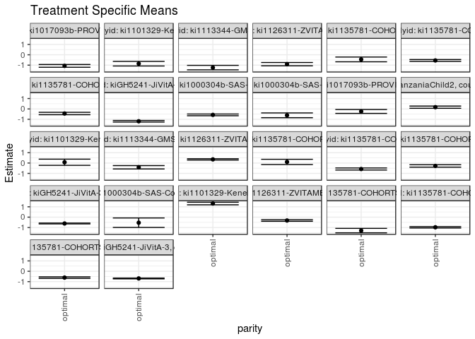

## Results Table

### Parameter: TSM

| agecat | studyid | country | intervention_level | baseline_level | estimate | ci_lower | ci_upper |
| --- | --- | --- | --- | --- | --- | --- | --- |
| Birth | ki1000304b-SAS-CompFeed | INDIA | optimal | observed | -0.5351641 | -0.9904736 | -0.0798546 |
| Birth | ki1101329-Keneba | GAMBIA | optimal | observed | 1.3148271 | 1.1911387 | 1.4385155 |
| Birth | ki1126311-ZVITAMBO | ZIMBABWE | optimal | observed | -0.3215184 | -0.3993791 | -0.2436577 |
| Birth | ki1135781-COHORTS | GUATEMALA | optimal | observed | -1.2972583 | -1.5120032 | -1.0825133 |
| Birth | ki1135781-COHORTS | INDIA | optimal | observed | -0.9768082 | -1.0441674 | -0.9094489 |
| Birth | ki1135781-COHORTS | PHILIPPINES | optimal | observed | -0.6088349 | -0.6823454 | -0.5353245 |
| Birth | kiGH5241-JiVitA-3 | BANGLADESH | optimal | observed | -0.6899047 | -0.7277156 | -0.6520937 |
| 6 months | ki1000304b-SAS-CompFeed | INDIA | optimal | observed | -0.5757433 | -0.6607003 | -0.4907862 |
| 6 months | ki1000304b-SAS-FoodSuppl | INDIA | optimal | observed | -0.6179698 | -0.8489845 | -0.3869552 |
| 6 months | ki1017093b-PROVIDE | BANGLADESH | optimal | observed | -0.2452628 | -0.4349760 | -0.0555495 |
| 6 months | ki1066203-TanzaniaChild2 | TANZANIA, UNITED REPUBLIC OF | optimal | observed | 0.1684252 | 0.0628093 | 0.2740412 |
| 6 months | ki1101329-Keneba | GAMBIA | optimal | observed | 0.0760902 | -0.2220355 | 0.3742159 |
| 6 months | ki1113344-GMS-Nepal | NEPAL | optimal | observed | -0.4084770 | -0.5693924 | -0.2475615 |
| 6 months | ki1126311-ZVITAMBO | ZIMBABWE | optimal | observed | 0.3520073 | 0.2884388 | 0.4155759 |
| 6 months | ki1135781-COHORTS | GUATEMALA | optimal | observed | 0.1062860 | -0.1457944 | 0.3583664 |
| 6 months | ki1135781-COHORTS | INDIA | optimal | observed | -0.5771723 | -0.6772365 | -0.4771080 |
| 6 months | ki1135781-COHORTS | PHILIPPINES | optimal | observed | -0.2799948 | -0.3964428 | -0.1635467 |
| 6 months | kiGH5241-JiVitA-3 | BANGLADESH | optimal | observed | -0.6108130 | -0.6520863 | -0.5695397 |
| 24 months | ki1017093b-PROVIDE | BANGLADESH | optimal | observed | -1.0698139 | -1.2020916 | -0.9375361 |
| 24 months | ki1101329-Keneba | GAMBIA | optimal | observed | -0.8566625 | -1.0798210 | -0.6335041 |
| 24 months | ki1113344-GMS-Nepal | NEPAL | optimal | observed | -1.2372057 | -1.4540349 | -1.0203764 |
| 24 months | ki1126311-ZVITAMBO | ZIMBABWE | optimal | observed | -0.9019364 | -1.0602396 | -0.7436331 |
| 24 months | ki1135781-COHORTS | GUATEMALA | optimal | observed | -0.4464956 | -0.6755801 | -0.2174111 |
| 24 months | ki1135781-COHORTS | INDIA | optimal | observed | -0.5469427 | -0.6360081 | -0.4578774 |
| 24 months | ki1135781-COHORTS | PHILIPPINES | optimal | observed | -0.4445452 | -0.5610402 | -0.3280503 |
| 24 months | kiGH5241-JiVitA-3 | BANGLADESH | optimal | observed | -1.1914457 | -1.2700226 | -1.1128687 |

### Parameter: E(Y)

| agecat | studyid | country | intervention_level | baseline_level | estimate | ci_lower | ci_upper |
| --- | --- | --- | --- | --- | --- | --- | --- |
| Birth | ki1000304b-SAS-CompFeed | INDIA | observed | observed | -0.2697590 | -0.5399211 | 0.0004030 |
| Birth | ki1101329-Keneba | GAMBIA | observed | observed | 1.7138545 | 1.6262621 | 1.8014469 |
| Birth | ki1126311-ZVITAMBO | ZIMBABWE | observed | observed | -0.5152877 | -0.5411394 | -0.4894359 |
| Birth | ki1135781-COHORTS | GUATEMALA | observed | observed | -1.0621429 | -1.1631387 | -0.9611471 |
| Birth | ki1135781-COHORTS | INDIA | observed | observed | -0.9498080 | -0.9874148 | -0.9122013 |
| Birth | ki1135781-COHORTS | PHILIPPINES | observed | observed | -0.7427251 | -0.7890855 | -0.6963647 |
| Birth | kiGH5241-JiVitA-3 | BANGLADESH | observed | observed | -0.7238886 | -0.7437224 | -0.7040548 |
| 6 months | ki1000304b-SAS-CompFeed | INDIA | observed | observed | -0.6657084 | -0.8024377 | -0.5289791 |
| 6 months | ki1000304b-SAS-FoodSuppl | INDIA | observed | observed | -0.9946381 | -1.1114079 | -0.8778682 |
| 6 months | ki1017093b-PROVIDE | BANGLADESH | observed | observed | -0.2083706 | -0.2927992 | -0.1239419 |
| 6 months | ki1066203-TanzaniaChild2 | TANZANIA, UNITED REPUBLIC OF | observed | observed | 0.0797179 | 0.0266621 | 0.1327737 |
| 6 months | ki1101329-Keneba | GAMBIA | observed | observed | -0.1874118 | -0.2456850 | -0.1291387 |
| 6 months | ki1113344-GMS-Nepal | NEPAL | observed | observed | -0.6047987 | -0.6909649 | -0.5186325 |
| 6 months | ki1126311-ZVITAMBO | ZIMBABWE | observed | observed | 0.3048076 | 0.2787350 | 0.3308802 |
| 6 months | ki1135781-COHORTS | GUATEMALA | observed | observed | 0.1940810 | 0.1226351 | 0.2655269 |
| 6 months | ki1135781-COHORTS | INDIA | observed | observed | -0.7068611 | -0.7417800 | -0.6719423 |
| 6 months | ki1135781-COHORTS | PHILIPPINES | observed | observed | -0.2938433 | -0.3352064 | -0.2524802 |
| 6 months | kiGH5241-JiVitA-3 | BANGLADESH | observed | observed | -0.5932502 | -0.6127743 | -0.5737261 |
| 24 months | ki1017093b-PROVIDE | BANGLADESH | observed | observed | -0.8879412 | -0.9708680 | -0.8050144 |
| 24 months | ki1101329-Keneba | GAMBIA | observed | observed | -0.7834078 | -0.8357743 | -0.7310414 |
| 24 months | ki1113344-GMS-Nepal | NEPAL | observed | observed | -1.1315863 | -1.2192240 | -1.0439487 |
| 24 months | ki1126311-ZVITAMBO | ZIMBABWE | observed | observed | -1.1802133 | -1.2803837 | -1.0800428 |
| 24 months | ki1135781-COHORTS | GUATEMALA | observed | observed | -0.2813755 | -0.3354674 | -0.2272835 |
| 24 months | ki1135781-COHORTS | INDIA | observed | observed | -0.6564729 | -0.6914450 | -0.6215007 |
| 24 months | ki1135781-COHORTS | PHILIPPINES | observed | observed | -0.6099592 | -0.6467541 | -0.5731643 |
| 24 months | kiGH5241-JiVitA-3 | BANGLADESH | observed | observed | -1.2971774 | -1.3204904 | -1.2738644 |

### Parameter: PAR

| agecat | studyid | country | intervention_level | baseline_level | estimate | ci_lower | ci_upper |
| --- | --- | --- | --- | --- | --- | --- | --- |
| Birth | ki1000304b-SAS-CompFeed | INDIA | optimal | observed | 0.2654051 | 0.0366219 | 0.4941882 |
| Birth | ki1101329-Keneba | GAMBIA | optimal | observed | 0.3990274 | 0.2984150 | 0.4996398 |
| Birth | ki1126311-ZVITAMBO | ZIMBABWE | optimal | observed | -0.1937692 | -0.2681103 | -0.1194282 |
| Birth | ki1135781-COHORTS | GUATEMALA | optimal | observed | 0.2351154 | 0.0371083 | 0.4331225 |
| Birth | ki1135781-COHORTS | INDIA | optimal | observed | 0.0270001 | -0.0286684 | 0.0826686 |
| Birth | ki1135781-COHORTS | PHILIPPINES | optimal | observed | -0.1338902 | -0.1938899 | -0.0738904 |
| Birth | kiGH5241-JiVitA-3 | BANGLADESH | optimal | observed | -0.0339839 | -0.0691167 | 0.0011488 |
| 6 months | ki1000304b-SAS-CompFeed | INDIA | optimal | observed | -0.0899651 | -0.1965938 | 0.0166636 |
| 6 months | ki1000304b-SAS-FoodSuppl | INDIA | optimal | observed | -0.3766683 | -0.6115746 | -0.1417620 |
| 6 months | ki1017093b-PROVIDE | BANGLADESH | optimal | observed | 0.0368922 | -0.1329478 | 0.2067322 |
| 6 months | ki1066203-TanzaniaChild2 | TANZANIA, UNITED REPUBLIC OF | optimal | observed | -0.0887073 | -0.1803813 | 0.0029666 |
| 6 months | ki1101329-Keneba | GAMBIA | optimal | observed | -0.2635020 | -0.5556316 | 0.0286276 |
| 6 months | ki1113344-GMS-Nepal | NEPAL | optimal | observed | -0.1963217 | -0.3557270 | -0.0369165 |
| 6 months | ki1126311-ZVITAMBO | ZIMBABWE | optimal | observed | -0.0471998 | -0.1062883 | 0.0118887 |
| 6 months | ki1135781-COHORTS | GUATEMALA | optimal | observed | 0.0877950 | -0.1569681 | 0.3325582 |
| 6 months | ki1135781-COHORTS | INDIA | optimal | observed | -0.1296888 | -0.2240895 | -0.0352882 |
| 6 months | ki1135781-COHORTS | PHILIPPINES | optimal | observed | -0.0138486 | -0.1242448 | 0.0965477 |
| 6 months | kiGH5241-JiVitA-3 | BANGLADESH | optimal | observed | 0.0175628 | -0.0190299 | 0.0541556 |
| 24 months | ki1017093b-PROVIDE | BANGLADESH | optimal | observed | 0.1818727 | 0.0564521 | 0.3072933 |
| 24 months | ki1101329-Keneba | GAMBIA | optimal | observed | 0.0732547 | -0.1441036 | 0.2906130 |
| 24 months | ki1113344-GMS-Nepal | NEPAL | optimal | observed | 0.1056193 | -0.1007440 | 0.3119827 |
| 24 months | ki1126311-ZVITAMBO | ZIMBABWE | optimal | observed | -0.2782769 | -0.4267510 | -0.1298029 |
| 24 months | ki1135781-COHORTS | GUATEMALA | optimal | observed | 0.1651201 | -0.0528842 | 0.3831244 |
| 24 months | ki1135781-COHORTS | INDIA | optimal | observed | -0.1095302 | -0.1934104 | -0.0256499 |
| 24 months | ki1135781-COHORTS | PHILIPPINES | optimal | observed | -0.1654139 | -0.2764214 | -0.0544065 |
| 24 months | kiGH5241-JiVitA-3 | BANGLADESH | optimal | observed | -0.1057317 | -0.1793681 | -0.0320953 |